# DGE analysis of SLCs

```r
# 2024.3.24
#if (!requireNamespace("BiocManager", quietly = TRUE))
#    install.packages("BiocManager")
#BiocManager::install("biomaRt")

#library(biomaRt)
```

```r
library(tidyverse)
```

```r
#library(stringr)
#library(dplyr)
library(limma)
library(edgeR)
library(ggplot2)
library(ggdendro)
library(pvclust)
library(gplots)
library(cluster)
library(igraph)
library(goseq)
library(treemap)
library(clusterProfiler)
library(org.Hs.eg.db)
library(RColorBrewer)
```

First we copy the [list of SLCs in mammalian genomes](https://esbl.nhlbi.nih.gov/Databases/SLC-list/) and convert gene IDs to ENSG IDs with tool on this [page](https://biit.cs.ut.ee/gprofiler/convert).Then we can select all SLCs in GTEx gene counts data file with `filter.py` in terminal.

```bash
python filter.py -f1 ../Input/gProfiler_hsapiens_12-11-2023_6-02-56\ AM.csv -f2 ../Input/bulk-gex_v8_rna-seq_GTEx_Analysis_2017-06-05_v8_RNASeQCv1.1.9_gene_reads.gct -o ../Input/GTEx_SLCs_gene_reads.gct
```

```r
tissue1 <- 'Heart'

# Load count data
counts.data <- read_tsv("../Input/GTEx_SLCs_gene_reads.gct")
samp.anno.data <- read_tsv("../Input/GTEx_Analysis_v8_Annotations_SampleAttributesDS.txt")
subj.anno.ds.data <- read_tsv("../Input/GTEx_Analysis_v8_Annotations_SubjectPhenotypesDS.txt")
```

```r
counts.data <- counts.data[,-1]

#counts.data.backup <- counts.data
#counts.data <- counts.data.backup

select <- dplyr::select

# Retrieve the count data of 2 among so many various tissues to analyse. Subsequent analysis should include all the data
tiss1.sampid <- samp.anno.data %>%
  filter(SMTS==tissue1) %>%
  select(SAMPID,SMTSD)

#tiss2.sampid <- samp.anno.data %>%
#  filter(SMTS==tissue2) %>%
#  select(SAMPID)

#counts.data <- counts.data.backup

#ids <- tiss1.sampid %>%
#  bind_rows(tiss2.sampid) %>%
#  add_row(SAMPID='Description') %>%
#  pull() %>%
#  paste(collapse="|")

ids <- tiss1.sampid %>%
#  bind_rows(tiss2.sampid) %>%
  add_row(SAMPID='Description') %>%
  .$SAMPID


counts.data <- counts.data %>%
  select(any_of(ids))

missing_ids <- ids[!ids %in% colnames(counts.data)]

#counts.data <- counts.data %>%
#  select(matches(ids))

genelist <- counts.data$Description

# For our subsequent analyses we want to reduce the data set to only those genes with some expression. In this case we will discard genes with no reads in >= 50 samples
counts.data <- counts.data[rowSums(counts.data[,-1]==0)<50,]

#cor.table <- cor(counts.data[,-1])
#cor.table %>% gplots::heatmap.2(dendrogram="row", trace = "none", col=viridis::viridis(25, begin=.25), margins=c(7,8))

# Create a tibble for edgeR description
#tiss1.sampid <- tiss1.sampid %>%
#  mutate(TS=tissue1)

#tiss2.sampid <- tiss2.sampid %>%
#  mutate(TS=tissue2)
```

Before we can normalize the data we need to be able to tell edgeR which groups the samples belong to. Here group refers to the distinct sample types (i.e. combinations of tissue, age, death circumstance)

```r
sample.description <- tiss1.sampid %>%
#  bind_rows(tiss2.sampid) %>%
  mutate(SUBJID=str_extract(SAMPID, 'GTEX-.+(?=-.+-SM)')) %>%
  left_join(subj.anno.ds.data, by='SUBJID') %>%
  mutate(group=paste(SMTSD, SEX, AGE, DTHHRDY, sep="_")) %>% # TS to SMTSD
  select(-SUBJID)

colnames(sample.description)[2] <- 'TS'

#sample.description <- sample.description %>%
#  mutate(SMTSD=factor(SMTSD,level = c("Brain - Frontal Cortex (BA9)","Brain - Cortex","Brain - Cerebellum","Brain - Cerebellar Hemisphere","Brain - Caudate (basal ganglia)","Brain - Nucleus accumbens (basal ganglia)","Brain - Putamen (basal ganglia)","Brain - Hypothalamus","Brain - Spinal cord (cervical c-1)","Brain - Hippocampus","Brain - Anterior cingulate cortex (BA24)","Brain - Substantia nigra","Brain - Amygdala")),
#         SEX=factor(SEX,levels = c(1,2)),
#         AGE=factor(AGE,levels = c("20-29","30-39","40-49","50-59","60-69","70-79")),
#         DTHHRDY=factor(DTHHRDY,levels = c(0,1,2,3,4)))

sample.description <- sample.description %>%
  mutate(
    TS = factor(TS, levels = unique(TS)),
    SEX = factor(SEX, levels = sort(unique(SEX))),  # numeric should be sorted
    AGE = factor(AGE, levels = c("20-29", "30-39", "40-49", "50-59", "60-69", "70-79")),
    DTHHRDY = factor(DTHHRDY, levels = sort(unique(DTHHRDY)))  # sort numerically
  )

sample.description
```

| SAMPID | TS | SEX | AGE | DTHHRDY | group |
| --- | --- | --- | --- | --- | --- |
| GTEX-1117F-0726-SM-5GIEN | Heart - Atrial Appendage | 2 | 60-69 | 4 | Heart - Atrial Appendage_2_60-69_4 |
| GTEX-111FC-0626-SM-5N9CU | Heart - Atrial Appendage | 1 | 60-69 | 1 | Heart - Atrial Appendage_1_60-69_1 |
| GTEX-111FC-0826-SM-5GZWO | Heart - Left Ventricle | 1 | 60-69 | 1 | Heart - Left Ventricle_1_60-69_1 |
| GTEX-111FC-0826-SM-CYKRT | Heart - Left Ventricle | 1 | 60-69 | 1 | Heart - Left Ventricle_1_60-69_1 |
| GTEX-111VG-0326-SM-5GZX7 | Heart - Atrial Appendage | 1 | 60-69 | 3 | Heart - Atrial Appendage_1_60-69_3 |
| GTEX-111YS-0326-SM-5GZZ3 | Heart - Atrial Appendage | 1 | 60-69 | 0 | Heart - Atrial Appendage_1_60-69_0 |
| GTEX-111YS-0426-SM-5987O | Heart - Left Ventricle | 1 | 60-69 | 0 | Heart - Left Ventricle_1_60-69_0 |
| GTEX-1122O-0626-SM-5N9B9 | Heart - Atrial Appendage | 2 | 60-69 | 0 | Heart - Atrial Appendage_2_60-69_0 |
| GTEX-1122O-0826-SM-5GICV | Heart - Left Ventricle | 2 | 60-69 | 0 | Heart - Left Ventricle_2_60-69_0 |
| GTEX-117XS-0726-SM-5H131 | Heart - Atrial Appendage | 1 | 60-69 | 2 | Heart - Atrial Appendage_1_60-69_2 |

[output cut: 1131 more lines]

Calculate normalization factors by TMM method while RPKM is poorly behaved statistically, and plot multidimensional scaling plot of distances between gene expression profiles by logFC methods instead of bcv due to the large quantity of samples

```r
counts.matrix <- counts.data %>% select(-Description) %>% as.matrix()
rownames(counts.matrix) <- counts.data$Description

sample.description <- tibble(SAMPID=colnames(counts.matrix)) %>%
  left_join(sample.description, by = join_by(SAMPID))

dge.data <- DGEList(counts=counts.matrix,
                    group=sample.description$group)

dge.data <- calcNormFactors(dge.data, method = "TMM")
dge.data$samples
```

|  | group | lib.size | norm.factors |
| --- | --- | --- | --- |
| GTEX-1117F-0726-SM-5GIEN | Heart - Atrial Appendage_2_60-69_4 | 439829 | 1.2320521 |
| GTEX-111FC-0626-SM-5N9CU | Heart - Atrial Appendage_1_60-69_1 | 522216 | 1.1545811 |
| GTEX-111FC-0826-SM-5GZWO | Heart - Left Ventricle_1_60-69_1 | 575723 | 1.0262235 |
| GTEX-111VG-0326-SM-5GZX7 | Heart - Atrial Appendage_1_60-69_3 | 451684 | 1.2586578 |
| GTEX-111YS-0326-SM-5GZZ3 | Heart - Atrial Appendage_1_60-69_0 | 560091 | 0.9178935 |
| GTEX-111YS-0426-SM-5987O | Heart - Left Ventricle_1_60-69_0 | 618504 | 0.7454587 |
| GTEX-1122O-0626-SM-5N9B9 | Heart - Atrial Appendage_2_60-69_0 | 742358 | 0.9645127 |
| GTEX-1122O-0826-SM-5GICV | Heart - Left Ventricle_2_60-69_0 | 602788 | 0.7760682 |
| GTEX-117XS-0726-SM-5H131 | Heart - Atrial Appendage_1_60-69_2 | 442333 | 1.1086468 |
| GTEX-117YW-0326-SM-5N9CY | Heart - Left Ventricle_1_50-59_3 | 246945 | 1.3342663 |

[output cut: 851 more lines]

```r
# Make a plot of the Biological Coefficient of Variation of each sample

# Try to find out if sample can be divided by variables (i.e. TS, AGE, SEX)

#plotMDS(dge.data,method="logFC",pch=matched_pchs,bg=matched_bgs,col=matched_cols,
#        cex=1.4, dim.plot=c(3,2))
```

[figure not shown]

```r
# Assuming sample.description is your data frame
#plot_info <- sample.description %>%
#  mutate(
#    AGE = factor(AGE),
#    SEX = factor(SEX, levels = c(1, 2), labels = c("Male", "Female")),
#    TS = factor(TS)  # TS column is same as SMTSD
#  )

plot_info <- sample.description %>%
  mutate(
    SEX = ifelse(is.na(SEX), "Unknown", SEX),  # Handle missing SEX
    SEX = factor(SEX, levels = c(1, 2, "Unknown"), labels = c("Male", "Female", "Unknown")),
    TS = factor(TS),
    AGE = as.character(AGE), #When AGE is a factor and ifelse() is used, it doesn't handle factors gracefully
    AGE = ifelse(is.na(AGE), "Unknown", AGE),# Handle missing AGE
    AGE = factor(AGE, levels = c("20-29", "30-39", "40-49", "50-59", "60-69", "70-79", "Unknown"))
      )


# Define colors and shapes dynamically
#library(RColorBrewer)
#display.brewer.pal(12, "Set3")

#colors_age <- RColorBrewer::brewer.pal(n = length(unique(plot_info$AGE)), name = "Set1")
#colors_tissue <- RColorBrewer::brewer.pal(n = length(unique(plot_info$TS)), name = "Set3")

#colors_tissue <- RColorBrewer::brewer.pal(n = length(unique(plot_info$TS)), name = "Set3")
colors_tissue <- colorRampPalette(RColorBrewer::brewer.pal(9, "Set3"))(length(unique(plot_info$TS)))

# Assign colors and shapes
#plot_info <- plot_info %>%
#  mutate(
#    col = colors_tissue[TS],  # Tissue colors
#    bg = colors_age[AGE],     # Age background colors
#    pch = ifelse(SEX == "Male", 21, 24)  # Sex shapes
#  )

#plot_info <- plot_info %>%
#  mutate(
#    bg = colors_tissue[TS],  # Tissue background colors
#    pch = ifelse(SEX == "Male", 21, 24)  # Sex shapes
#  )

plot_info <- plot_info %>%
  mutate(
    bg = colors_tissue[TS], # Tissue colors
    pch = ifelse(SEX == "Male", 21, ifelse(SEX == "Female", 24, 22))  # Shape: default for unknown
  )


matched_bgs <- plot_info$bg[match(colnames(dge.data), plot_info$SAMPID)]
matched_pchs <- plot_info$pch[match(colnames(dge.data), plot_info$SAMPID)]
#matched_cols <- plot_info$col[match(colnames(dge.data), plot_info$SAMPID)]


# Increase the right margin to make space for the legend
par(mar=c(5, 4, 4, 12) + 0.1)  # Default is c(5, 4, 4, 2) + 0.1



#plotMDS(dge.data,method="logFC",pch=matched_pchs,bg=matched_bgs,col=matched_cols,
#        cex=1.4, dim.plot=c(1,2))

plotMDS(dge.data,method="logFC",pch=matched_pchs,bg=matched_bgs,cex=1.4,
        dim.plot=c(1,2))

# Adding a legend for Age outside the bottom of the plot
#legend("topright", inset=c(-0.2, 0.2), title="Age", legend=levels(plot_info$AGE), fill=unique(plot_info$bg), cex=0.8, y.intersp=0.7, xpd=TRUE)
# Adding a legend for Sex outside the top left of the plot
legend("topright", inset=c(-0.2, 0), title="Sex", legend=levels(plot_info$SEX), pch=unique(plot_info$pch), cex=0.6, y.intersp=0.7, xpd=TRUE)
# Adding a legend for Tissue outside the top right of the plot
legend("bottomright", inset=c(-0.45, 0), title="Tissue", legend=levels(plot_info$TS), fill=unique(plot_info$bg), pch=21, cex=0.6, y.intersp=0.7, border=unique(plot_info$bg), xpd=TRUE)
```

```r
# Assuming sample.description is your data frame
plot_info <- sample.description %>%
  mutate(
    AGE = factor(AGE),
    SEX = factor(SEX, levels = c(1, 2), labels = c("Male", "Female")),
    TS = factor(TS)  # TS column is same as SMTSD
  )

# Define colors and shapes dynamically
#library(RColorBrewer)
#display.brewer.pal(12, "Set3")

#colors_age <- RColorBrewer::brewer.pal(n = length(unique(plot_info$AGE)), name = "Set1")
#colors_tissue <- RColorBrewer::brewer.pal(n = length(unique(plot_info$TS)), name = "Set3")

#colors_age <- RColorBrewer::brewer.pal(n = length(unique(plot_info$AGE)), name = "Set3")
colors_age <- colorRampPalette(RColorBrewer::brewer.pal(9, "Set3"))(length(unique(plot_info$AGE)))


# Assign colors and shapes
#plot_info <- plot_info %>%
#  mutate(
#    col = colors_tissue[TS],  # Tissue colors
#    bg = colors_age[AGE],     # Age background colors
#    pch = ifelse(SEX == "Male", 21, 24)  # Sex shapes
#  )

plot_info <- plot_info %>%
  mutate(
    bg = colors_age[AGE],  # Tissue background colors
    pch = ifelse(SEX == "Male", 21, 24)  # Sex shapes
  )


matched_bgs <- plot_info$bg[match(colnames(dge.data), plot_info$SAMPID)]
matched_pchs <- plot_info$pch[match(colnames(dge.data), plot_info$SAMPID)]
#matched_cols <- plot_info$col[match(colnames(dge.data), plot_info$SAMPID)]


# Increase the right margin to make space for the legend
par(mar=c(5, 4, 4, 8) + 0.1)  # Default is c(5, 4, 4, 2) + 0.1



#plotMDS(dge.data,method="logFC",pch=matched_pchs,bg=matched_bgs,col=matched_cols,
#        cex=1.4, dim.plot=c(1,2))

plotMDS(dge.data,method="logFC",pch=matched_pchs,bg=matched_bgs,cex=1.4,
        dim.plot=c(1,2))

# Adding a legend for Age outside the bottom of the plot
#legend("topright", inset=c(-0.2, 0.2), title="Age", legend=levels(plot_info$AGE), fill=unique(plot_info$bg), cex=0.8, y.intersp=0.7, xpd=TRUE)
# Adding a legend for Sex outside the top left of the plot
legend("topright", inset=c(-0.2, 0), title="Sex", legend=levels(plot_info$SEX), pch=unique(plot_info$pch), cex=0.8, y.intersp=0.7, xpd=TRUE)
# Adding a legend for Tissue outside the top right of the plot
legend("bottomright", inset=c(-0.2, 0), title="Age", legend=levels(plot_info$AGE), fill=unique(plot_info$bg), pch=21, cex=0.8, y.intersp=0.7, border=unique(plot_info$bg), xpd=TRUE)
```

[output not shown]

```r
# Filter out genes with low mean normalized counts (no need to do it as there's
# no gene could be filterd out here)
#avg_log_cpm <- rowMeans(cpm(dge.data, log=TRUE))
#min_log_cpm <- 0.5  # For example, log2 CPM of 0.5
#keep <- avg_log_cpm > min_log_cpm
#counts_filtered_final <- counts.matrix[keep, ]

counts.data.normal <- cpm(dge.data)

# or log2 transformed:
counts.data.normal.log <- cpm(dge.data,log = TRUE)

# Assuming the first column might be non-numeric and should be excluded from the operation
counts.data[,-1] <- sapply(counts.data[,-1], function(x) as.numeric(as.character(x)))
# Check if there are any NAs introduced by incorrect conversions
sum(is.na(counts.data))
```

```
## [1] 322
```

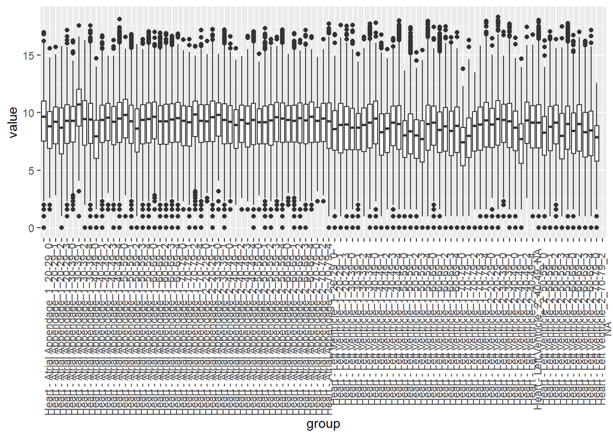

```r
counts.data.log <- log2(counts.data[,-1] + 1)

counts.data.log.pvt <- counts.data.log

counts.data.log.pvt <- counts.data.log.pvt %>%
  pivot_longer(colnames(counts.data.log.pvt), names_to="sample", values_to="value")

counts.data.log.pvt <- sample.description %>%
  select(SAMPID, group) %>%
  right_join(counts.data.log.pvt, by=join_by(SAMPID==sample))

counts.data.log.pvt %>% ggplot(aes(x=group, y=value)) +
  geom_boxplot() +
  theme(axis.text.x = element_text(angle = 90))
```